# 09.Example 1

Modified

Fr 2024-09-06 06:56

## Given:

Air at a pressure of $6\ \mathrm{kPa}$ and a temperature of $300\ \mathrm{°C}$ flows with a velocity of $10\ \frac{\mathrm{m}}{\mathrm{s}}$ over a flat plate $0.5\ \mathrm{m}$ long.

Figure 1: Flat Plate

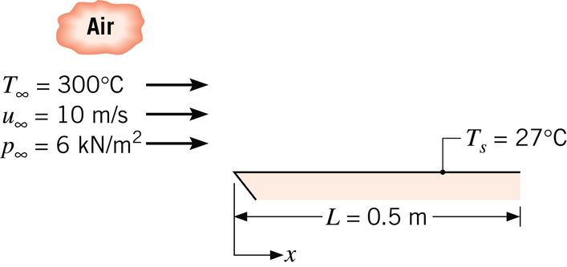

## Required:

Estimate the cooling rate per unit width of the plate needed to maintain it at a surface temperature of $27\ \mathrm{°C}$.

## Solution:

Start first by defining all of the given values.

$$P = 6\ \mathrm{kPa}$$
$$T_\infty = 300\ \mathrm{°C} = 573.15\ \mathrm{K}$$
$$u_\infty = 10\ \frac{\mathrm{m}}{\mathrm{s}}$$
$$L = 0.5\ \mathrm{m}$$
$$T_s = 27\ \mathrm{°C} = 300.15\ \mathrm{K}$$

The film temperature is given

$$T_f = \frac{T_\infty + T_s}{2} = 436.6\ \mathrm{K} = 163.5\ \mathrm{°C}$$

Going to Table A.4 @ $T_f$ shows that interpolation is needed. This is shown below.

$$T_A = 400\ \mathrm{K} = 126.9\ \mathrm{°C}$$
$$T_B = 450\ \mathrm{K} = 176.9\ \mathrm{°C}$$
$$\nu_A = 2.641\times 10^{-5}\ \frac{\mathrm{m}^{2}}{\mathrm{s}}$$
$$\nu_B = 3.239\times 10^{-5}\ \frac{\mathrm{m}^{2}}{\mathrm{s}}$$
$$\nu_1 = \frac{T_f - T_A}{T_B - T_A}(\nu_B - \nu_A) + \nu_A = 3.079\times 10^{-5}\ \frac{\mathrm{m}^{2}}{\mathrm{s}}$$
$$k_A = 0.0338\ \frac{\mathrm{W}}{\left(\mathrm{K} \cdot \mathrm{m}\right)}$$
$$k_B = 0.0373\ \frac{\mathrm{W}}{\left(\mathrm{K} \cdot \mathrm{m}\right)}$$
$$k = \frac{T_f - T_A}{T_B - T_A}(k_B - k_A) + k_A = 36.37\ \frac{\mathrm{mW}}{\left(\mathrm{K} \cdot \mathrm{m}\right)}$$
$$Pr_A = 0.69$$
$$Pr_B = 0.686$$
$$Pr = \frac{T_f - T_A}{T_B - T_A}(Pr_B - Pr_A) + Pr_A = 0.6871$$

Table A.4 values are for atmospheric pressure (i.e. $1 atm$). However, the actually pressure is at $P=6 kPa$. It is known that the thermal conductivity $k$ and Prandtl number $Pr$ are independent of pressure. However, the kinematic viscosity $\nu$ is not independent on pressure. Previously, it was shown that the kinematic viscosity is inversely related to the pressure. That is

$$\frac{\nu_2}{\nu_1}=\frac{P_1}{P_2}$$

For this particular case, this becomes

$$\nu = \nu_1 \frac{1 atm}{P} = 0.00052002\ \frac{\mathrm{m}^{2}}{\mathrm{s}}$$

The Reynolds number is then

$$Re_L = \frac{u_\infty L}{\nu} = 9615.0$$

Since $Re_L \lt Re_{x,c} = 5 \times 10^{5}$, the flow is laminar. For laminar flow across a flat plate, the following empirical relation is valid.

$$\bar{Nu}_L = 0.664 Re_L^{\frac{1}{2}} Pr^{\frac{1}{3}} = 57.45$$

The definition for the Nusselt number may be used to find the average convective coefficient. This is shown below.

$$\bar{Nu}_L=\frac{\bar{h} L}{k}$$

Solving for the average convective coefficient shows

$$\bar{h}_L = \frac{\bar{Nu_L} k}{L} = 4.179\ \frac{\mathrm{W}}{\left(\mathrm{K} \cdot \mathrm{m}^{2}\right)}$$

The required cooling rate per unit width is given by

Answer: $q^{\prime} = \bar{h} L (T_\infty - T_s) = 570.4\ \frac{\mathrm{W}}{\mathrm{m}}$